# Predicting Post-Graduation Earnings Using Tuition, Institutional Metrics, and Student Demographics

INFO 523 - Final Project

Project description

Author

Affiliation

Ava Lasater

College of Information Science, University of Arizona

## Introduction

The rising cost of higher education in the United States has intensified concerns about whether attending college is worth it for students. Families increasingly weigh tuition, financial aid, and borrowing against expected earnings after graduation, yet the relationships between these factors and long-term outcomes are complex and difficult to observe directly. This project uses the U.S. Department of Education’s College Scorecard dataset to investigate how institutional cost, student composition, and academic performance are associated with post-graduation earnings.

The analysis focuses on bachelor’s-degree-granting institutions and examines three main domains: cost of attendance (tuition and student debt), institutional characteristics (enrollment, sector, region, and locale), and student outcomes (retention, completion, and earnings). Two complementary modeling strategies are used. First, linear and penalized regression models estimate how these factors relate to median earnings ten years after enrollment. Second, logistic regression and random forest classifiers predict whether an institution falls above or below the sample median earnings level and identify which features are most important for classification. The goal is not to make causal claims, but to characterize patterns in the data and highlight which institutional features are most strongly associated with economic outcomes for graduates.

## Data Preprocessing

The first preprocessing step involved separating the College Scorecard dataset into smaller CSV files due to GitHub’s file size restrictions. Dividing the dataset enabled successful upload and version control. Once stored in the repository, the individual files were reassembled to create a complete dataset that was saved for future use.

A subset of variables was then selected to represent three important factors: cost metrics, institutional characteristics, and student outcome measures. These categories were chosen to capture factors related to university prestige, which will impact cost, overall financial burden of attendance, and student success.

The dataset was further restricted by selecting institutions that primarily award bachelor’s degrees. This decision reflects structural differences in educational pathways across types of schools. For example, retention and completion rates could be defined inconsistently for two-year or certificate programs, where many students enroll without the intention of completing a degree. Additionally, undergraduate degrees were prioritized because graduate school outcomes will likely be very different and impacted highly by field of study. Limiting the dataset to primarily bachelor’s–degree-granting institutions ensures that outcome measures are comparable.

Next, there was a significant amount of missing values in the dataset. Columns such as demographic columns and certain expense columns were removed from the dataset due to a large amount of missing values and inability to confidently impute missing values. No values were imputed to prioritize data fidelity, since missing values could have resulted from institutional reporting practices or idiosyncrasies.

Prior to examining individual variables, the distribution of institutions from a geological and control (private vs. public) perspective were examined to ensure that filtering steps did not inadvertently remove entire regions. Histograms comparing the original and cleaned datasets show that U.S. regions and control groups remain represented similarly.

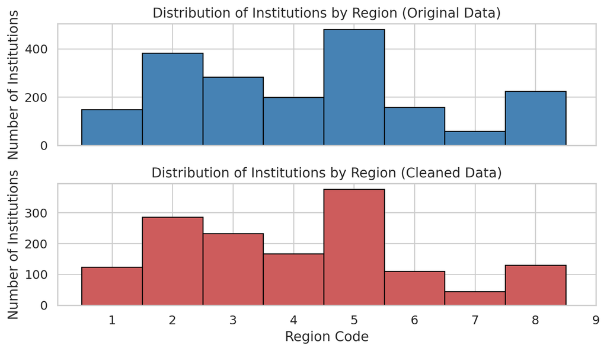

```python
fig, axes = plt.subplots(2, 1, figsize=(8.5, 5), sharex=True)
# orginial distribution
axes[0].hist(college_data_selected['REGION'], bins=np.arange(1, 10)-0.5, edgecolor='black', color='steelblue')
axes[0].set_title('Distribution of Institutions by Region (Original Data)')
axes[0].set_ylabel('Number of Institutions')
# final distribution
axes[1].hist(college_final['REGION'], bins=np.arange(1, 10)-0.5, edgecolor='black', color='indianred')
axes[1].set_title('Distribution of Institutions by Region (Cleaned Data)')
axes[1].set_xlabel('Region Code')
axes[1].set_ylabel('Number of Institutions')
axes[1].set_xticks(range(1, 10))
plt.tight_layout()
plt.show()
```

Figure 1. Distribution of institutions by region in original data (top) and cleaned data (bottom). The region codes correspond to the following regions: 0:’U.S. Service Schools, 1: New England, 2: Mid East, 3: Great Lakes, 4: Plains, 5: Southeast, 6: Southwest, 7: Rocky Mountains, 8: Far West, 9: Outlying Areas.

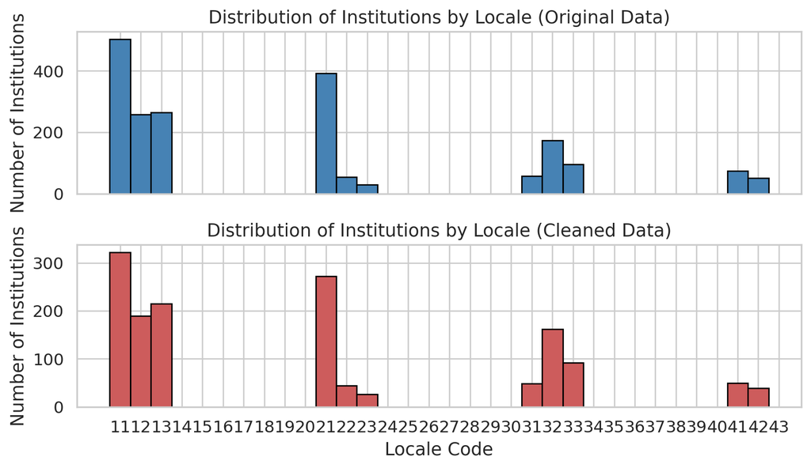

```python
fig, axes = plt.subplots(2, 1, figsize=(8.5,5), sharex=True)
# orginial distribution
axes[0].hist(college_data_selected['LOCALE'], bins=np.arange(11, 44)-0.5,
             edgecolor='black', color='steelblue')
axes[0].set_title('Distribution of Institutions by Locale (Original Data)')
axes[0].set_ylabel('Number of Institutions')
# final distribution
axes[1].hist(college_final['LOCALE'], bins=np.arange(11, 44)-0.5,
             edgecolor='black', color='indianred')
axes[1].set_title('Distribution of Institutions by Locale (Cleaned Data)')
axes[1].set_xlabel('Locale Code')
axes[1].set_ylabel('Number of Institutions')
axes[1].set_xticks(range(11, 44))
plt.tight_layout()
plt.show()
```

Figure 2. Distribution of institutions by locale in original data (top) and cleaned data (bottom). The locale codes correspond to the following locales: 11: ‘City: Large’, 12: ‘City: Midsize’, 13: ‘City: Small’, 21: ‘Suburb: Large’, 22: ‘Suburb: Midsize’, 23: ‘Suburb: Small’, 31: ‘Town: Fringe’, 32: ‘Town: Distant’, 33: ‘Town: Remote’, 41: ‘Rural: Fringe’, 42: ‘Rural: Distant’, 43: ‘Rural: Remote.’

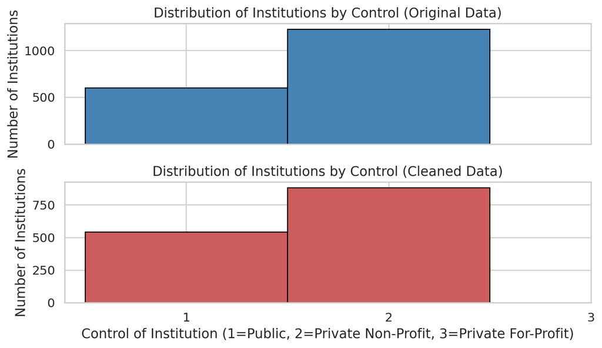

```python
fig, axes = plt.subplots(2, 1, figsize=(8.5,5), sharex=True)
# orginial distribution
axes[0].hist(college_data_selected['CONTROL'], bins=np.arange(1, 4)-0.5,
             edgecolor='black', color='steelblue')
axes[0].set_title('Distribution of Institutions by Control (Original Data)')
axes[0].set_ylabel('Number of Institutions')
# final distribution
axes[1].hist(college_final['CONTROL'], bins=np.arange(1, 4)-0.5,
             edgecolor='black', color='indianred')
axes[1].set_title('Distribution of Institutions by Control (Cleaned Data)')
axes[1].set_xlabel('Control of Institution (1=Public, 2=Private Non-Profit, 3=Private For-Profit)')
axes[1].set_ylabel('Number of Institutions')
axes[1].set_xticks(range(1, 4))
plt.tight_layout()
plt.show()
```

Figure 3. Distribution of institutions by control (private vs public) in the original data (top), and the cleaned data (bottom).

## Exploratory Data analysis

After preprocessing and initial variable selection, an exploratory data analysis was conducted to understand the distribution of key variables, identify structural patterns in the dataset, and evaluate suitability of each variable. The EDA focuses on the three major domains described previously: cost of attendance, institutional characteristics, and student outcomes.

A series of histograms was generated for each numerical variable retained in the dataset.

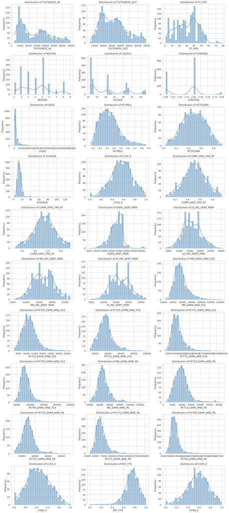

```python
numerical_columns = college_final.select_dtypes(include=['number']).columns
n_cols = 3  # number of plots per row
n_rows = math.ceil(len(numerical_columns) / n_cols)

fig, axes = plt.subplots(n_rows, n_cols, figsize=(18, n_rows * 4))
axes = axes.flatten()

for i, col in enumerate(numerical_columns):
    sns.histplot(college_final[col], bins=30, kde=True, color='steelblue', ax=axes[i])
    axes[i].set_title(f'Distribution of {col}')
    axes[i].set_xlabel(col)
    axes[i].set_ylabel('Frequency')

# Turn off any unused subplots
for j in range(i + 1, len(axes)):
    axes[j].axis('off')

plt.tight_layout()
plt.show()
```

Figure 4. Histograms of all retained numerical variables.

When looking at the cost metrics, in-state and out-of-state tuition both skewed to the right, with most institutions clustered between $10,000 and $40,000. There were some schools that had much higher tuition rates, which likely suggest highly selective and prodigious universities.

Considering the institutional characteristics, enrollment size shows a severe right skew, with most institutions enrolling between 1,000 and 6,000 undergraduates. However there is a long tail of universities with the maximum enrollment of 156,755. This outlier is Southern New Hampshire University. This institution has both in-person and online campuses that contributes to the large number of students. Since this represents a meaningful difference, no outlier removal was performed, though log-transformations may be used for visualization. Next, the student-to-faculty ratio is highly skewed, driven by a small number of likely specialized institutions with unusually high ratios. This can vary greatly depending on how schools report these numbers, so this column was removed before further analysis was conducted. Finally, the completion and retention rates are bounded between 0 and 1, with many institutions clustered toward the high end of the distribution. There are several schools with 0% completion rate within 4 years, but with completion rates existing for 6 and 8 years. Schools which had 0% completion for 4, 6, and 8 years were removed from the data since they may indicate errors or initially unreported data. Similarly, there were three schools with 0% retention rates. One of these schools is closed, so it does not have retention data, and the other two seem to be missing the data. Here, as well, the schools with 0% retention were removed from the dataset.

For the outcome metrics, debt measures appear approximately normally distributed with not extreme outliers. Earning percentiles show a strong right skew, reflecting the wide variation in early-career earnings across institutions. The median earnings follow a more moderate skew and can be used as a more stable proxy for early-career earnings.

A correlation matrix was created to begin to understand the relationships present in the dataset.

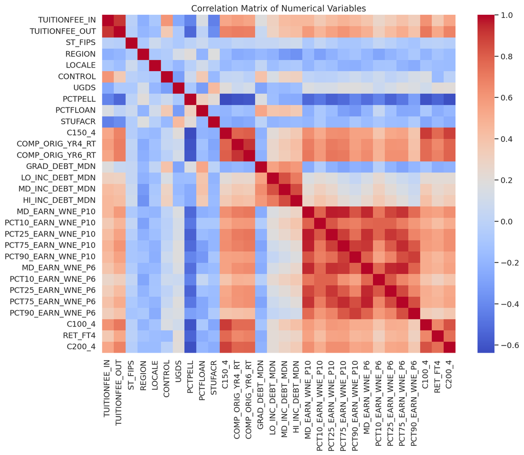

```python
numerical_columns = college_final.select_dtypes(include=['number']).columns
plt.figure(figsize=(12, 10))
correlation_matrix = college_final[numerical_columns].corr()
sns.heatmap(correlation_matrix, annot=False, fmt=".2f", cmap='coolwarm', cbar=True)
plt.title('Correlation Matrix of Numerical Variables')
plt.tight_layout()
plt.show()
```

Figure 5. Correlation matrix expressing relationships between numerical variables.

## Models

### Linear Regression

For the regression analysis, the target feature is the median earnings after 10 years. This was selected since it captures a large span of time, and will be less influenced by institutional differences than completion and retention. This allows for a more clear relationship between financial features, while still controlling for differences in institution type and locale. Skewed variables were log transformed, and all the features not already on a 0 to 1 scale were scaled.

Variance inflation factors (VIFs) were examined to assess multicollinearity. Most predictors had VIF values below 5, indicating low multicollinearity. Tuition variables showed higher VIFs due to strong correlation between in-state and out-of-state tuition. To address this, out-of-state tuition was removed, and the model retained only in-state tuition as the primary cost predictor.

Although Pell Grant share and the private nonprofit indicator had VIFs slightly above 10, these were retained because they represent essential institutional characteristics related to socioeconomic composition and governance. Their inclusion was theoretically justified despite moderate multicollinearity.

After removing the highly collinear variable out-of-state tuition, the linear regression model remained stable with an adjusted R² of 0.566, indicating that the selected institutional characteristics explain approximately 57% of the variation in median earnings ten years after enrollment. The revised model substantially reduced multicollinearity and produced more interpretable coefficients.

The OLS coefficient plot highlights several clear patterns in how institutional features relate to median earnings 10 years after enrollment. The strongest positive predictors are in-state tuition, first-year retention (RET_FT4), four-year completion rates (C100_4), and enrollment size (UGDS). These variables reflect institutional resources and student success—factors that consistently align with higher post-graduation earnings.

On the negative side, PCTPELL (share of Pell Grant recipients) is the most influential predictor, indicating that institutions serving more low-income students tend to report lower median earnings, a pattern likely driven by socioeconomic factors rather than institutional quality alone. Several regional indicators (e.g., Southeast, Rocky Mountains, Outlying Areas) and rural locale categories also show negative associations, suggesting geographic labor-market effects.

Overall, the coefficient patterns reinforce that student success metrics and institutional characteristics—rather than cost alone—play the largest role in explaining variation in long-term earnings across colleges.

```
VIF for column TUITIONFEE_IN: 6.627719294941651
VIF for column GRAD_DEBT_MDN: 1.4776585382263423
VIF for column RET_FT4: 2.312433722391724
VIF for column C100_4: 2.8746536989258455
VIF for column PCTPELL: 10.312988226760478
VIF for column UGDS: 1.9040601973511277
VIF for column REGION_Mid East: 2.7052965862963343
VIF for column REGION_Great Lakes: 2.321261938457216
VIF for column REGION_Plains: 2.052175761435485
VIF for column REGION_Southeast: 3.771093967271536
VIF for column REGION_Southwest: 1.836876786142022
VIF for column REGION_Rocky Mountains: 1.3086780559627693
VIF for column REGION_Far West: 1.8280703727114536
VIF for column REGION_Outlying Areas: 1.4279454923878028
VIF for column LOCALE_City: Midsize: 1.498021023269829
VIF for column LOCALE_City: Small: 1.548674124768067
VIF for column LOCALE_Suburb: Large: 1.7183040205004247
VIF for column LOCALE_Suburb: Midsize: 1.0973732836085437
VIF for column LOCALE_Suburb: Small: 1.0796533700920188
VIF for column LOCALE_Town: Fringe: 1.1196175848605272
VIF for column LOCALE_Town: Distant: 1.5091786108447816
VIF for column LOCALE_Town: Remote: 1.3109194505528656
VIF for column LOCALE_Rural: Fringe: 1.1577471075235253
VIF for column LOCALE_Rural: Distant: 1.1241922681964742
VIF for column LOCALE_Rural: Remote: 1.098914421602895
VIF for column CONTROL_Private Non-Profit: 12.431094345081371
VIF for column CONTROL_Private For-Profit: 1.7321735861926806
                            Results: Ordinary least squares
=======================================================================================
Model:                      OLS                    Adj. R-squared:           0.566
Dependent Variable:         MD_EARN_WNE_P10        AIC:                      24995.3926
Date:                       2025-12-12 15:30       BIC:                      25137.3729
No. Observations:           1177                   Log-Likelihood:           -12470.
Df Model:                   27                     F-statistic:              57.77
Df Residuals:               1149                   Prob (F-statistic):       2.22e-192
R-squared:                  0.576                  Scale:                    9.5549e+07
---------------------------------------------------------------------------------------
                              Coef.     Std.Err.    t    P>|t|     [0.025      0.975]
---------------------------------------------------------------------------------------
const                       72332.8353 1682.0508 43.0028 0.0000  69032.5999  75633.0706
```

[output cut: 23 more lines]

```
LOCALE_Rural: Distant       -3586.8716 1908.3061 -1.8796 0.0604  -7331.0268    157.2837
LOCALE_Rural: Remote        -5718.1622 2670.0337 -2.1416 0.0324 -10956.8505   -479.4739
CONTROL_Private Non-Profit  -6501.0122 1471.1905 -4.4189 0.0000  -9387.5332  -3614.4912
CONTROL_Private For-Profit   -830.2815 2106.7142 -0.3941 0.6936  -4963.7196   3303.1566
---------------------------------------------------------------------------------------
Omnibus:                     486.560             Durbin-Watson:                1.959
Prob(Omnibus):               0.000               Jarque-Bera (JB):             4827.179
Skew:                        1.631               Prob(JB):                     0.000
Kurtosis:                    12.370              Condition No.:                22
=======================================================================================
Notes:
[1] Standard Errors assume that the covariance matrix of the errors is correctly
specified.
Mean Squared Error: 110300510.89
R-squared: 0.4855
```

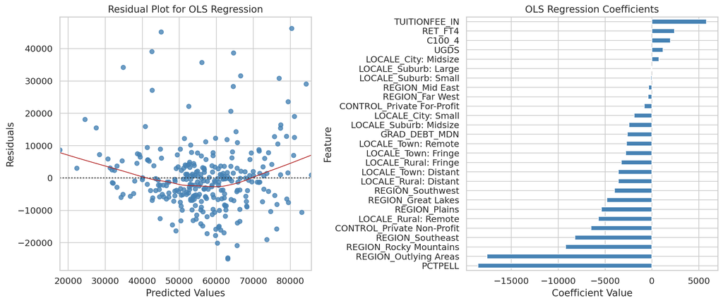

```python
# Dropping out of state tutition since it is highly correlated with in-state tuition
college_regression_v2 = college_regression.drop(columns=['TUITIONFEE_OUT'])

# now we can rerun the model with the reduced set of variables
# split the dataset
y = college_regression_v2['MD_EARN_WNE_P10']
# X = all columns except the target
X = college_regression_v2.drop(columns=['MD_EARN_WNE_P10'])
# Train-test split
X_train, X_test, y_train, y_test = train_test_split(X, y, test_size = 0.2, random_state = 42)

# Adding a constant for OLS
X_train_with_const = sm.add_constant(X_train)
X_test_with_const = sm.add_constant(X_test)

# Fitting the OLS model
model = sm.OLS(y_train, X_train_with_const).fit()

# Making predictions
y_pred = model.predict(X_test_with_const)

# Evaluating the model
# creating a residual plot
X_test_with_const = sm.add_constant(X_test)
predictions = model.predict(X_test_with_const)
predictions = pd.to_numeric(predictions, errors='coerce')
residuals = y_test - predictions
residuals = pd.to_numeric(residuals, errors='coerce').fillna(0)

VIFs = [variance_inflation_factor(X.values, i) for i in range(X.shape[1])]
for idx, vif in enumerate(VIFs):
    print(f"VIF for column {X.columns[idx]}: {vif}")

# first, let's look at the model results
model_summary2 = model.summary2()
print(model_summary2)

# Calculating MSE
mse = mean_squared_error(y_test, y_pred)
print(f'Mean Squared Error: {mse:.2f}')

# Extracting Adjusted R-squared from the model's summary
r2 = r2_score(y_test, y_pred)
print(f'R-squared: {r2:.4f}')

ols_coefs = pd.Series(model.params, index=X_train_with_const.columns)
ols_coefs = ols_coefs.drop('const')  # remove intercept for cleaner plot

# Combined Plot
fig, axes = plt.subplots(1, 2, figsize=(14, 6))

# Residual Plot
sns.residplot(
    x=predictions,
    y=residuals,
    lowess=True,
    color='steelblue',
    line_kws={'color': 'firebrick', 'lw': 1},
    ax=axes[0]
)
axes[0].set_xlabel('Predicted Values')
axes[0].set_ylabel('Residuals')
axes[0].set_title('Residual Plot for OLS Regression')

# Coefficient Plot
ols_coefs.sort_values().plot(
    kind='barh',
    color='steelblue',
    ax=axes[1]
)
axes[1].set_title("OLS Regression Coefficients")
axes[1].set_xlabel("Coefficient Value")
axes[1].set_ylabel("Feature")

plt.tight_layout()
plt.show()
```

Figure 6. Residual plot (left) shows curvature and heteroscedasticity, indicating model misfit in the OLS regression. Coefficient plot (right) highlights key predictors: in-state tuition, retention, completion rates, and enrollment size have positive associations with earnings, while Pell share and certain regions show strong negative effects.

### Ridge Regression

Both in-state and out-of-state tuition variables were retained in the Ridge model to preserve important financial information, despite their correlation. After refitting Ridge regression with both predictors, the model achieved the same R² (≈ 0.49) and nearly identical residual behavior compared to the reduced model. This confirms that Ridge regression effectively stabilizes coefficient estimates in the presence of multicollinearity while preserving the interpretive value of key financial predictors.

```
Ridge Regression:
Mean Squared Error: 110226157.793066
R-squared: 0.48583010161522244
```

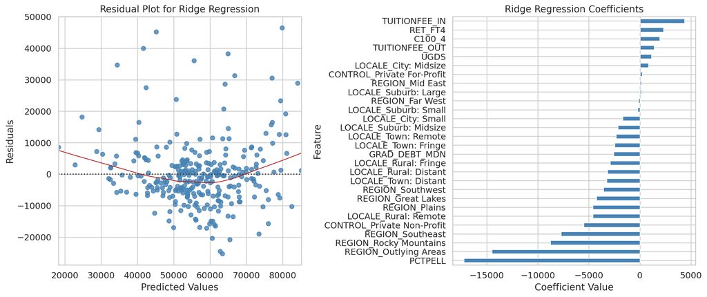

```python
# using data with both tutition columns for ridge regression
y = college_regression['MD_EARN_WNE_P10']
# X = all columns except the target
X = college_regression.drop(columns=['MD_EARN_WNE_P10'])
# Train-test split
X_train, X_test, y_train, y_test = train_test_split(X, y, test_size = 0.2, random_state = 42)

# ridge regression
X_train, X_test, y_train, y_test = train_test_split(X, y, test_size = 0.2, random_state = 42)

# Add a constant to the model (for statsmodels)
X_train_const = sm.add_constant(X_train)
X_test_const = sm.add_constant(X_test)

# Initialize the Ridge Regression model
ridge_reg = Ridge(alpha = 1)  # Alpha is the regularization strength; adjust accordingly

# Fit the model
ridge_reg.fit(X_train, y_train)

# Predict on the testing set
r_y_pred = ridge_reg.predict(X_test)

# Calculate and print the MSE
mse = mean_squared_error(y_test, r_y_pred)
print('Ridge Regression:')
print(f'Mean Squared Error: {mse}')

# Compute residuals for ridge regression
r2 = r2_score(y_test, r_y_pred)
print(f'R-squared: {r2}')

residuals = y_test - r_y_pred

# Prepare coefficient series
ridge_coefs = pd.Series(ridge_reg.coef_, index=X_train.columns)

fig, axes = plt.subplots(1, 2, figsize=(14, 6))

# Residual Plot
sns.residplot(
    x=r_y_pred,
    y=residuals,
    lowess=True,
    color='steelblue',
    line_kws={'color': 'firebrick', 'lw': 1},
    ax=axes[0]
)
axes[0].set_xlabel('Predicted Values')
axes[0].set_ylabel('Residuals')
axes[0].set_title('Residual Plot for Ridge Regression')

# Coefficient Plot
ridge_coefs.sort_values().plot(
    kind='barh',
    color='steelblue',
    ax=axes[1]
)
axes[1].set_title("Ridge Regression Coefficients")
axes[1].set_xlabel("Coefficient Value")
axes[1].set_ylabel("Feature")

plt.tight_layout()
plt.show()
```

Figure 7. Residual plot (left) for the Ridge model shows similar curvature and heteroscedasticity patterns as OLS, indicating remaining nonlinear structure in the data. Coefficient plot (right) reveals stabilized effect sizes: tuition, retention, completion, and enrollment have the strongest positive associations with earnings, while Pell share and several regional indicators exert the largest negative influences.

### Feature Selection for Classification

To simplify the model and focus on the most informative predictors, two feature selection methods were applied. First, SelectKBest identified the top 15 variables most strongly associated with the high- vs. low-earnings outcome. Second, a Random Forest classifier was used to rank features by importance, capturing nonlinear effects and interactions. The final feature set was created by taking the union of the top features from both methods, ensuring that only the most relevant predictors were retained for classification.

```
Top 15 features:
Index(['TUITIONFEE_IN', 'TUITIONFEE_OUT', 'GRAD_DEBT_MDN', 'RET_FT4', 'C100_4',
       'PCTPELL', 'UGDS', 'REGION_Mid East', 'REGION_Southeast',
       'REGION_Far West', 'LOCALE_Suburb: Large', 'LOCALE_Town: Distant',
       'LOCALE_Town: Remote', 'LOCALE_Rural: Remote',
       'CONTROL_Private For-Profit'],
      dtype='object')
```

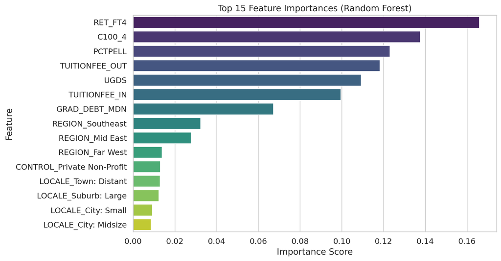

```python
# Need to create the target variable
median_income = college_regression['MD_EARN_WNE_P10'].median()
college_regression['HighEarnings'] = (college_regression['MD_EARN_WNE_P10'] >= median_income).astype(int)

# defining X and y
X = college_regression.drop(columns=['MD_EARN_WNE_P10', 'HighEarnings'])
y = college_regression['HighEarnings']
 # using SelectKBest for feature selection
# used https://scikit-learn.org/stable/modules/generated/sklearn.feature_selection.SelectKBest.html
selector = SelectKBest(k=15)
x_new = selector.fit_transform(X, y)

selected_features = X.columns[selector.get_support()]
print('Top 15 features:')
print(selected_features)

# used https://scikit-learn.org/stable/auto_examples/ensemble/plot_forest_importances.html
# creating a random forest
rf = RandomForestClassifier(random_state=42)
rf.fit(X, y)

# determing the importances
importances = pd.Series(rf.feature_importances_, index=X.columns)
# picking the top importances
top_importances = importances.sort_values(ascending=False).head(15)

plt.figure(figsize=(10, 6))
sns.barplot(x=top_importances.values, y=top_importances.index, palette='viridis')
plt.title('Top 15 Feature Importances (Random Forest)')
plt.xlabel('Importance Score')
plt.ylabel('Feature')
plt.show()

# filtering for just the top features from these two anayses
final_features = list(set(selected_features) | set(top_importances.index))
X_final = X[final_features].copy()

X_train, X_test, y_train, y_test = train_test_split(
    X, y, test_size=0.2, random_state=42, stratify=y
)
```

Figure 8. Random Forest feature importance rankings show that retention (RET_FT4), 4-year completion (C100_4), Pell share (PCTPELL), tuition levels, and enrollment size (UGDS) are the strongest predictors of whether an institution is classified as high-earning. Regional indicators and locale categories contribute modestly, while most fine-grained institutional descriptors have relatively minor influence.

Next, permutation importance showed that institution size (UGDS) and first-year retention were the strongest predictors of whether an institution falls into the high-earning category. Cost-related variables and socioeconomic composition (PCTPELL) also contributed substantially, while several regional indicators (Southeast, Mid East) demonstrated meaningful predictive value. In contrast, many locale categories and institutional control types had only minor influence on classification performance, suggesting that structural and academic characteristics matter more than geographic setting.

```
UGDS                          0.075480
RET_FT4                       0.071073
TUITIONFEE_OUT                0.053898
PCTPELL                       0.038079
REGION_Southeast              0.036497
C100_4                        0.034915
REGION_Mid East               0.031073
GRAD_DEBT_MDN                 0.024068
TUITIONFEE_IN                 0.010169
LOCALE_City: Midsize          0.006102
REGION_Far West               0.004294
LOCALE_Suburb: Large          0.003955
LOCALE_Town: Fringe           0.003390
LOCALE_Town: Distant          0.003164
CONTROL_Private Non-Profit    0.002260
dtype: float64
```

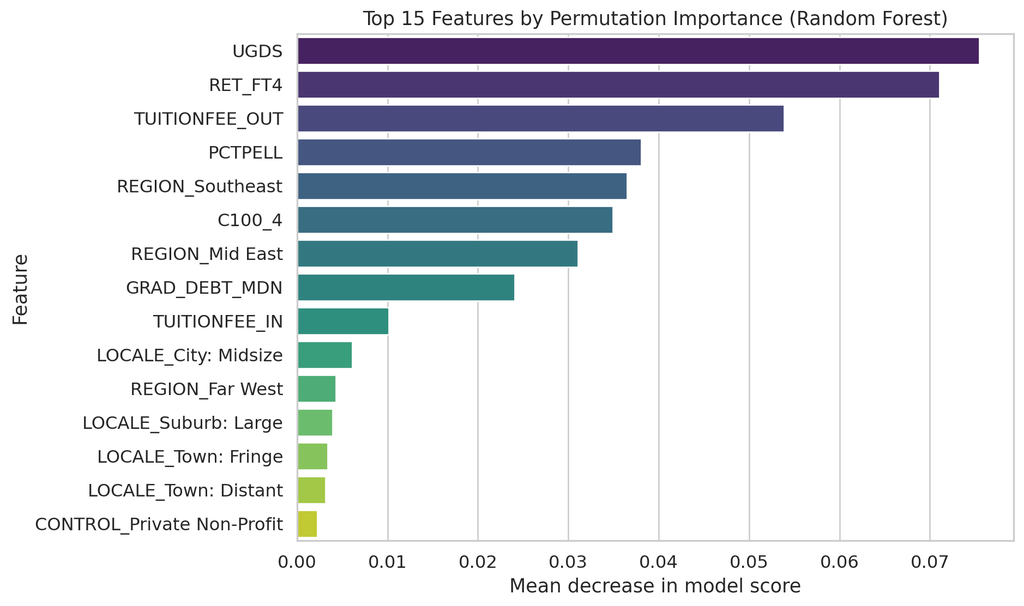

```python
# compute permutation importance on the test set
result = permutation_importance(
    rf,
    X_test,
    y_test,
    n_repeats=30,       # number of shuffles per feature
    random_state=42,
    n_jobs=-1
)

# put into a Series for easy viewing
perm_importances = pd.Series(
    result.importances_mean,
    index=X_test.columns
).sort_values(ascending=False)

# look at the top 15
top_perm = perm_importances.head(15)
print(top_perm)

# plot the top 15 permutation importances
plt.figure(figsize=(10, 6))
sns.barplot(x=top_perm.values, y=top_perm.index, palette='viridis')
plt.xlabel("Mean decrease in model score")
plt.ylabel("Feature")
plt.title("Top 15 Features by Permutation Importance (Random Forest)")
plt.tight_layout()
plt.show()
```

Figure 9. Permutation importance results from the Random Forest model show that enrollment size (UGDS), retention (RET_FT4), tuition levels, and Pell share (PCTPELL) are the most influential predictors of high-earning institutions. Regional indicators and completion rates also contribute meaningfully, while finer-grained locale and control variables have comparatively minor effects

### Logistic Regression

```
k-Fold F1-Score: 0.80
k-Fold CV took 0.11 seconds

Logistic Regression Accuracy: 0.7728813559322034
Logistic Regression Precision: 0.7775823831391786
Logisitc Regression Recall: 0.7728813559322034
Logistic Regression F-1 Score: 0.7719854657317307
```

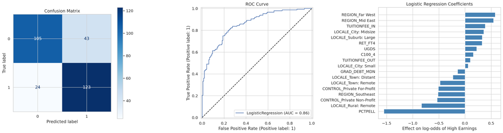

```python
X_train, X_test, y_train, y_test = train_test_split(
    X_final, y, test_size=0.2, random_state=42, stratify=y
)

# Building the logistic regression model
log_reg = LogisticRegression(multi_class = 'multinomial', solver = 'lbfgs', max_iter = 1000, random_state = 42)
log_reg.fit(X_train, y_train)

# Cross validation
start_time = time.time()
kf = KFold(n_splits = 5)
kf_f1_scores = cross_val_score(log_reg, X_train, y_train, cv = kf, scoring = 'f1_weighted')
kf_f1_average = np.mean(kf_f1_scores)
print(f"k-Fold F1-Score: {kf_f1_average:.2f}")
kfold_time = time.time() - start_time
print(f"k-Fold CV took {kfold_time:.2f} seconds")

# Making predictions
log_predictions = log_reg.predict(X_test)
print()
print("Logistic Regression Accuracy:", accuracy_score(y_test, log_predictions))
print("Logistic Regression Precision:", precision_score(y_test, log_predictions, average = 'weighted'))
print("Logisitc Regression Recall:", recall_score(y_test, log_predictions, average = 'weighted'))
print("Logistic Regression F-1 Score:", f1_score(y_test, log_predictions, average = 'weighted'))

# Visualizations

fig, axes = plt.subplots(1, 3, figsize=(22, 6))

# Confusion Matrix
ConfusionMatrixDisplay.from_estimator(log_reg, X_test, y_test, cmap='Blues', ax=axes[0])
axes[0].set_title("Confusion Matrix")

# ROC Curve
RocCurveDisplay.from_estimator(log_reg, X_test, y_test, ax=axes[1])
axes[1].plot([0, 1], [0, 1], 'k--')
axes[1].set_title("ROC Curve")

# Coefficient Plot
coef = pd.Series(log_reg.coef_[0], index=X_final.columns)
coef = coef.sort_values()

axes[2].barh(coef.index, coef.values, color='steelblue')
axes[2].set_title("Logistic Regression Coefficients")
axes[2].set_xlabel("Effect on log-odds of High Earnings")

plt.tight_layout()
plt.show()
```

Figure 10. Logistic regression diagnostics showing classification performance (confusion matrix and ROC curve) and the relative influence of predictors (coefficient plot).

### Random Forest

```
Random Forest Cross Validation
k-Fold F1-Score: 0.81
k-Fold CV took 1.10 seconds

Random Forest Accuracy: 0.7830508474576271
Random Forest Precision: 0.7874173284342775
Random Forest Recall: 0.7830508474576271
Random Forest F-1 Score: 0.7822854623732566
```

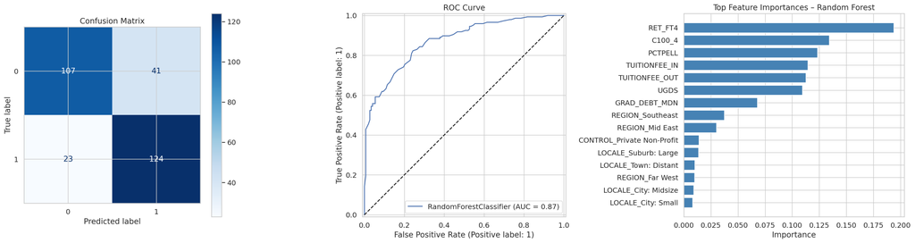

```python
# creating model

rf_classifier = RandomForestClassifier()
rf_classifier.fit(X_train, y_train)
rf_predictions = rf_classifier.predict(X_test)

# cross validation for random forest
print('Random Forest Cross Validation')
start_time = time.time()
kf = KFold(n_splits = 5)
kf_f1_scores = cross_val_score(rf_classifier, X_train, y_train, cv = kf, scoring = 'f1_weighted')
kf_f1_average = np.mean(kf_f1_scores)
print(f"k-Fold F1-Score: {kf_f1_average:.2f}")
kfold_time = time.time() - start_time
print(f"k-Fold CV took {kfold_time:.2f} seconds")

# final evaluation metrics X
print()
print("Random Forest Accuracy:", accuracy_score(y_test, rf_predictions))
print("Random Forest Precision:", precision_score(y_test, rf_predictions, average = 'weighted'))
print("Random Forest Recall:", recall_score(y_test, rf_predictions, average = 'weighted'))
print("Random Forest F-1 Score:", f1_score(y_test, rf_predictions, average = 'weighted'))

# visualzations
fig, axes = plt.subplots(1, 3, figsize=(22, 6))

# Confusion Matrix
ConfusionMatrixDisplay.from_estimator(rf_classifier, X_test, y_test, cmap='Blues', ax=axes[0])
axes[0].set_title("Confusion Matrix")

# ROC Curve
RocCurveDisplay.from_estimator(rf_classifier, X_test, y_test, ax=axes[1])
axes[1].plot([0, 1], [0, 1], 'k--')
axes[1].set_title("ROC Curve")

# Feature Importance
rf_importances = pd.Series(rf_classifier.feature_importances_, index=X_test.columns)
rf_importances = rf_importances.sort_values(ascending=True).tail(15)

axes[2].barh(rf_importances.index, rf_importances.values, color='steelblue')
axes[2].set_title("Top Feature Importances – Random Forest")
axes[2].set_xlabel("Importance")

plt.tight_layout()
plt.show()
```

The calibration curve shows that both Logistic Regression and Random Forest produce probability estimates that track the 45° perfect calibration line closely across most probability bins. Logistic Regression remains slightly smoother and more consistent, but the Random Forest model also follows the ideal trend well, with only mild deviations in the mid-range. Neither model exhibits the severe overconfidence or step-like jumps that Random Forests often display on poorly structured problems. Overall, Logistic Regression provides the most stable calibration, but Random Forest achieves comparable reliability while offering slightly stronger classification performance. These results indicate that both models produce usable probability estimates, though Logistic Regression remains the safer choice when precise probability calibration is important.

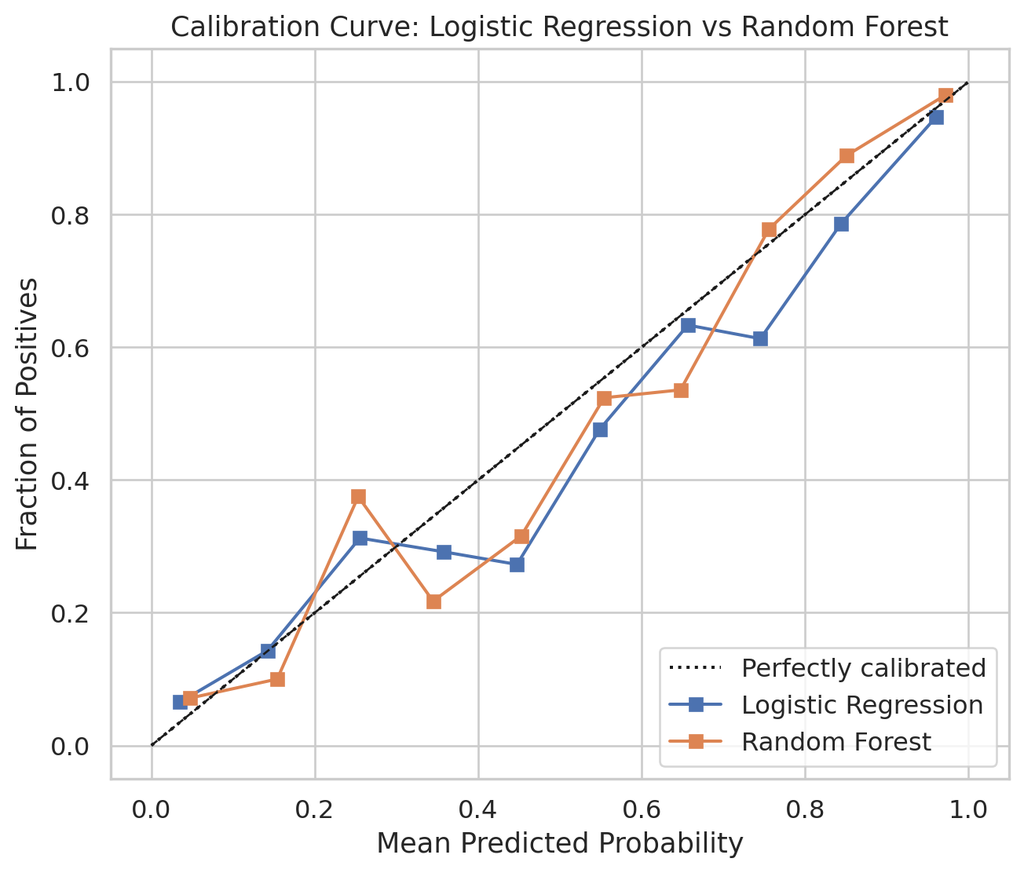

```python
# Calibration Curve
# https://scikit-learn.org/stable/modules/calibration.html to help create this plot
plt.figure(figsize=(7, 6))

# Logistic Regression
CalibrationDisplay.from_estimator(
    log_reg, X_test, y_test, n_bins=10, name="Logistic Regression", ax=plt.gca()
)

# Random Forest
CalibrationDisplay.from_estimator(
    rf_classifier, X_test, y_test, n_bins=10, name="Random Forest", ax=plt.gca()
)

plt.title("Calibration Curve: Logistic Regression vs Random Forest")
plt.xlabel("Mean Predicted Probability")
plt.ylabel("Fraction of Positives")
plt.plot([0,1], [0,1], 'k--', linewidth=1)  # perfect calibration line
plt.tight_layout()
plt.show()
```

Figure 12. Calibration curve comparing Logistic Regression and Random Forest. Logistic Regression shows slightly smoother calibration than the Random Forest.

## Evalutation

Overall, the regression and classification results tell a consistent story. The ordinary least squares and Ridge regression models explain roughly half of the variation in median earnings ten years after enrollment, with in-state tuition, retention, completion, and Pell share emerging as key predictors. However, diagnostic plots show curvature, heteroscedasticity, and heavy-tailed residuals, indicating that linear models do not fully capture the structure of the data and should be interpreted primarily as describing average trends rather than providing precise predictions for individual institutions.

Several limitations should be noted. The analysis is based on cross-sectional, institution-level aggregates and cannot separate institutional effects from differences in student populations, academic programs, or local impacts. Important factors such as major, selectivity, and student academic preparation are not modeled explicitly. In addition, missing data and reporting variation in the College Scorecard may introduce noise or bias. Finally, all models estimate associations rather than causal effects. Higher tuition or higher retention may correlate with earnings for reasons unrelated to the policies of a particular institution.

## Conclusion

This project examined how tuition, financial burden, institutional characteristics, and student success metrics relate to post-graduation earnings using the College Scorecard dataset. Across both regression and classification approaches, tuition and student debt measures were associated with earnings, but institutional performance and student composition were as important. Institutions with higher retention and completion rates tended to have higher median earnings, while those serving larger shares of Pell Grant recipients tended to have lower earnings, consistent with underlying socioeconomic differences. Regional indicators also played a role, reflecting geographic wage disparities.

The modeling results suggest that the cost of an institution is an imperfect proxy for long-term outcomes. Higher-tuition institutions often have stronger earnings, but this relationship is intertwined with selectivity, student demographics, and academic success. Classification models show that a combination of enrollment size, retention, completion, tuition, and Pell share provides the strongest predictive power, while fine-grained locale categories and control type contribute relatively little once other factors are accounted for.

Future work could extend this analysis by incorporating program-level data (e.g., major fields), longitudinal trends over multiple cohorts, or student-level information where available. Methods such as causal inference or matching designs could help disentangle institutional impact from student selection. Nevertheless, the findings here provide a useful descriptive map of how cost, institutional characteristics, and student outcomes align with graduates’ early-career earnings across U.S. colleges and universities.

## References

Buitinck, L., Louppe, G., Blondel, M., Pedregosa, F., & Mueller, A. (2024). Permutation importance (Version 1.4) [Documentation]. scikit-learn. https://scikit-learn.org/stable/modules/permutation_importance.html

scikit-learn developers. (2024). Plotting feature importance for forests of trees [Example]. https://scikit-learn.org/stable/auto_examples/ensemble/plot_forest_importances.html

U.S. Department of Education. (2024). College Scorecard Data [Data set]. Office of Federal Student Aid. https://collegescorecard.ed.gov/data/